# Descriptive Analysis

# 1. Data Overview

```r
skim_without_charts(Y_Cyclistic_V2)
```

```
-- Data Summary ------------------------
                           Values
Name                       Y_Cyclistic_V2
Number of rows             3876042
Number of columns          16
_______________________
Column type frequency:
  character                10
  Date                     1
  difftime                 1
  factor                   1
  numeric                  3
________________________
Group variables            None

-- Variable type: character ---------------------------------------------------------------------------------------------------------------------------------------
# A tibble: 10 x 8
   skim_variable      n_missing complete_rate   min   max empty n_unique whitespace
 * <chr>                  <int>         <dbl> <int> <int> <int>    <int>      <int>
 1 ride_id                   15          1.00     8    16     0  3876027          0
 2 started_at                15          1.00    19    19     0  3358846          0
 3 ended_at                  15          1.00    19    19     0  3296031          0
 4 rideable_type             15          1.00     1    11     0     6004          0
 5 start_station_name        15          1.00    10    43     0      642          0
 6 end_station_name          15          1.00     5    43     0      644          0
 7 member_casual             15          1.00     6     6     0        2          0
 8 month                     15          1.00     2     2     0       12          0
 9 day                       15          1.00     2     2     0       31          0
10 year                      15          1.00     4     4     0        2          0

-- Variable type: Date --------------------------------------------------------------------------------------------------------------------------------------------
# A tibble: 1 x 7
  skim_variable n_missing complete_rate min        max        median     n_unique
* <chr>             <int>         <dbl> <date>     <date>     <date>        <int>
1 date                 15          1.00 2019-04-01 2020-03-31 2019-08-14      366

-- Variable type: difftime ----------------------------------------------------------------------------------------------------------------------------------------
# A tibble: 1 x 7
  skim_variable n_missing complete_rate min    max          median n_unique
* <chr>             <int>         <dbl> <drtn> <drtn>       <time>    <int>
1 ride_length          15          1.00 1 secs 9383424 secs 11'52"    22109

-- Variable type: factor ------------------------------------------------------------------------------------------------------------------------------------------
# A tibble: 1 x 6
  skim_variable n_missing complete_rate ordered n_unique top_counts
* <chr>             <int>         <dbl> <lgl>      <int> <chr>
1 weekday              15          1.00 TRUE           7 Tue: 598955, Wed: 592786, Thu: 586856, Mon: 575492

-- Variable type: numeric -----------------------------------------------------------------------------------------------------------------------------------------
# A tibble: 3 x 10
  skim_variable    n_missing complete_rate  mean     sd    p0   p25   p50   p75  p100
* <chr>                <int>         <dbl> <dbl>  <dbl> <dbl> <dbl> <dbl> <dbl> <dbl>
1 start_station_id        15          1.00 202.  157.       1    77   174   290   673
2 end_station_id          15          1.00 203.  157.       1    77   174   291   675
3 start_hour              15          1.00  13.8   4.71     0    10    15    17    23
```

#2. Member/Casual Comparison

As the goal of this project is to better understand the how different customer types use the Cyclistic bike service, let’s start by looking at some summary statistics.

## 2.1 Summary statistics

| member_casual | ride_mean | ride_median | ride_max | ride_min |
| --- | --- | --- | --- | --- |
| casual | 3552.8218 secs | 00:25:46 | 9383424 secs | 2 secs |
| member | 850.0727 secs | 00:09:49 | 9060234 secs | 1 secs |

## 2.2 Compare members and casual users - Weekdays

```r
Y_Cyclistic_V2 %>%
  drop_na() %>%
  group_by(weekday, member_casual) %>%
  summarize( ride_mean = mean(ride_length)) %>%
  arrange(member_casual, weekday)
```

| weekday | member_casual | ride_mean |
| --- | --- | --- |
| Sunday | casual | 3581.5240 secs |
| Monday | casual | 3372.3915 secs |
| Tuesday | casual | 3596.3202 secs |
| Wednesday | casual | 3718.7398 secs |
| Thursday | casual | 3683.0548 secs |
| Friday | casual | 3773.8939 secs |
| Saturday | casual | 3331.9826 secs |
| Sunday | member | 920.0235 secs |
| Monday | member | 842.5726 secs |
| Tuesday | member | 826.1640 secs |

[output cut: 4 more lines]

```r
Y_Cyclistic_V2 %>%
  group_by(weekday, member_casual) %>%
  summarize( avg_duration = mean(ride_length), number_of_rides = n()) %>%
  arrange(member_casual, weekday)
```

| weekday | member_casual | avg_duration | number_of_rides |
| --- | --- | --- | --- |
| Sunday | casual | 3581.5240 secs | 181289 |
| Monday | casual | 3372.3915 secs | 103296 |
| Tuesday | casual | 3596.3202 secs | 90510 |
| Wednesday | casual | 3718.7398 secs | 92457 |
| Thursday | casual | 3683.0548 secs | 102679 |
| Friday | casual | 3773.8939 secs | 122404 |
| Saturday | casual | 3331.9826 secs | 209543 |
| Sunday | member | 920.0235 secs | 267954 |
| Monday | member | 842.5726 secs | 472196 |
| Tuesday | member | 826.1640 secs | 508445 |

[output cut: 5 more lines]

```r
Y_Cyclistic_V2 %>%
  drop_na() %>%
  group_by(weekday, member_casual) %>%
  summarize( avg_duration = mean(ride_length), number_of_rides = n()) %>%
  arrange(member_casual, weekday)
```

| weekday | member_casual | avg_duration | number_of_rides |
| --- | --- | --- | --- |
| Sunday | casual | 3581.5240 secs | 181289 |
| Monday | casual | 3372.3915 secs | 103296 |
| Tuesday | casual | 3596.3202 secs | 90510 |
| Wednesday | casual | 3718.7398 secs | 92457 |
| Thursday | casual | 3683.0548 secs | 102679 |
| Friday | casual | 3773.8939 secs | 122404 |
| Saturday | casual | 3331.9826 secs | 209543 |
| Sunday | member | 920.0235 secs | 267954 |
| Monday | member | 842.5726 secs | 472196 |
| Tuesday | member | 826.1640 secs | 508445 |

[output cut: 4 more lines]

Looking at the above data, it is noticeable that casual members take longer trips than members (+ 4x). But members perform a bigger amount of trips.

We’ll create a graph in order to better visualize the total number of rides per rider type

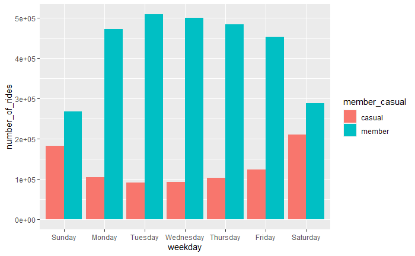

```r
Y_Cyclistic_V2 %>%
  drop_na %>%
  group_by(weekday, member_casual) %>%
  summarize(number_of_rides = n()) %>%
  arrange(member_casual, weekday) %>%
  ggplot(aes(x = weekday, y = number_of_rides, fill = member_casual)) + geom_col(position = "dodge")
```

visualize the average ride duration

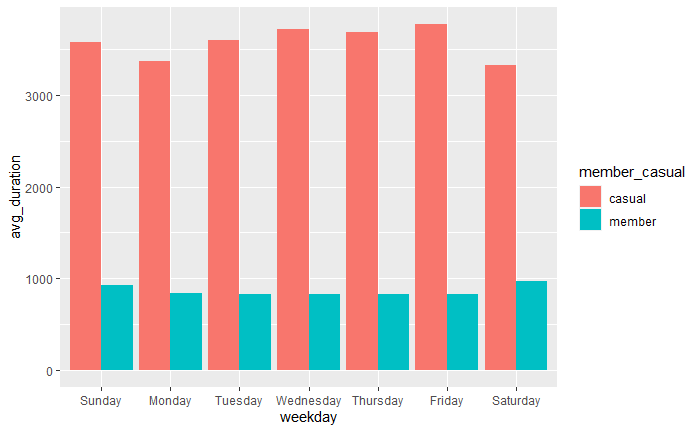

```r
Y_Cyclistic_V2 %>%
  drop_na %>%
  group_by(member_casual, weekday) %>%
  summarize(avg_duration = mean(ride_length)) %>%
  arrange(member_casual, weekday) %>%
  ggplot(aes(x = weekday, y = avg_duration, fill = member_casual)) + geom_col(position = "dodge")
```

By looking at the graph, we’re able to understand that: - on a daily basis, the average duration of casual trips tends to be approximately 4 longer than member trips. - member trips seem to always be averaging 900 sec = 15 mins - casual trips always exceed the 3000 sec = 50 min mark, peaking on Friday

## 2.2 Compare members and casual users - Hourly

```r
Y_Cyclistic_V2 %>%
  group_by(start_hour, member_casual) %>%
  summarize( avg_duration = mean(ride_length), number_of_rides = n()) %>%
  arrange(member_casual, start_hour)
```

| start_hour | member_casual | avg_duration | number_of_rides |
| --- | --- | --- | --- |
| 0 | casual | 6257.5108 secs | 8363 |
| 1 | casual | 6232.2107 secs | 5491 |
| 2 | casual | 6233.4502 secs | 3361 |
| 3 | casual | 10215.3123 secs | 1982 |
| 4 | casual | 7592.0192 secs | 1196 |
| 5 | casual | 5941.0810 secs | 2690 |
| 6 | casual | 3984.8447 secs | 6291 |
| 7 | casual | 1932.0531 secs | 13302 |
| 8 | casual | 3289.2525 secs | 22304 |
| 9 | casual | 4091.6481 secs | 29057 |

[output cut: 39 more lines]

We’re able to tell that the number of trips increases during normal commuting hours, but we need to create a graph to better visualize the data

total number of rides per rider type

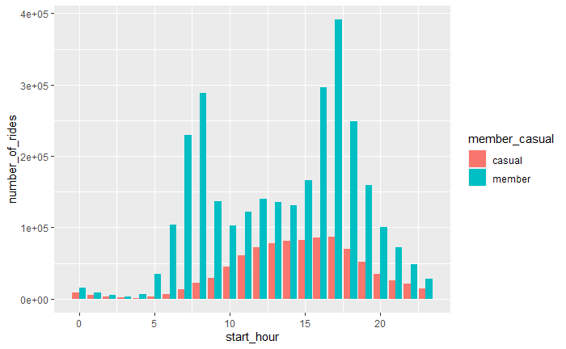

```r
Y_Cyclistic_V2 %>%
  drop_na %>%
  group_by(start_hour, member_casual) %>%
  summarize(number_of_rides = n()) %>%
  arrange(member_casual, start_hour) %>%
  ggplot(aes(x = start_hour, y = number_of_rides, fill = member_casual)) + geom_col(position = "dodge")
```

We’re able to see that: - members usually outperform casuals in terms of trip numbers, except for the early morning hours (0-5AM), during which both groups perform a similarly small number of trips - members perform a bigger number of rides during commuting hours (7-8AM and 4-5PM) - the number of casual trips increases during the morning period, stabilizing from 11AM to 5PM, and then decreasing similarly to the morning rate.